# Better Graphs

## 10.3 Case 2 — Berkeley: put the denominator beside the percentage

The Berkeley admissions example concerns the six largest departments in 1973, not the entire university. The dataset contains 4,526 applications and is associated with the Bickel, Hammel and O’Connell paper. Our counts follow [R’s documentation](https://stat.ethz.ch/R-manual/R-devel/library/datasets/html/UCBAdmissions.html) and [numeric source](https://raw.githubusercontent.com/wch/r-source/trunk/src/library/datasets/data/UCBAdmissions.R). We preserve the source’s male/female categories; those are historical labels, not a complete framework for gender. Unlike the previous paired example, these are observational admissions counts.

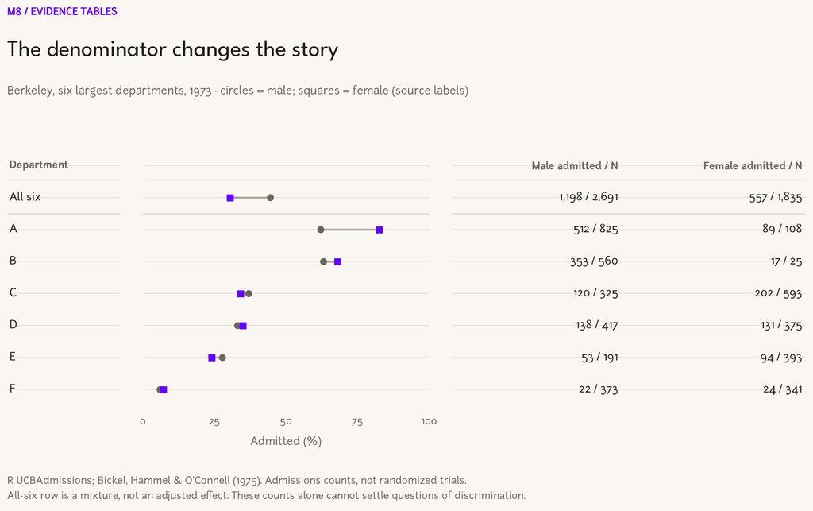

Figure 6: The integrated table makes mixture weights visible: a rate is not an account of how many applications it represents.

```python
et.berkeley_figure()
plt.show()
```

**The design move:** do not repair an aggregation trap with a paragraph alone. Give department and aggregate results different blocks, place admitted/N beside the marks, and leave the rate axis common. The all-six row summarizes a mixture of departments. It is not a covariate-adjusted estimate, and these counts cannot by themselves decide whether a system is fair. We display descriptive rates without inventing sampling intervals for a model we have not specified.

```python
counts, male_n, female_n, male_rate, female_rate = et.berkeley_records()
et.markdown_table(["Department", "Male admitted/N", "Male rate (%)", "Female admitted/N", "Female rate (%)"],
    [(name, f"{c[0]}/{mn}", f"{mr:.1f}", f"{c[2]}/{fn}", f"{fr:.1f}")
     for name,c,mn,fn,mr,fr in zip(["All six","A","B","C","D","E","F"],
         counts,male_n,female_n,male_rate,female_rate)])
```

| Department | Male admitted/N | Male rate (%) | Female admitted/N | Female rate (%) |
| --- | --- | --- | --- | --- |
| All six | 1198/2691 | 44.5 | 557/1835 | 30.4 |
| A | 512/825 | 62.1 | 89/108 | 82.4 |
| B | 353/560 | 63.0 | 17/25 | 68.0 |
| C | 120/325 | 36.9 | 202/593 | 34.1 |
| D | 138/417 | 33.1 | 131/375 | 34.9 |
| E | 53/191 | 27.7 | 94/393 | 23.9 |
| F | 22/373 | 5.9 | 24/341 | 7.0 |

**Transfer to experiments:** keep the denominator and the unit of analysis attached to every result. A trial with 80 people measured ten times is not automatically a trial with 800 independent observations. Our proposed table template makes this a visible design decision, not a detail hidden in a methods file.

## 10.4 Case 3 — Three trials: show the effect of the comparison

The following experiments are **synthetic**, not attributed to a published study. All use a task-completion time endpoint; within each illustrative trial, the arms and participants are independent. We deliberately center generated values to give effects of 6, 3 and 1 seconds, then bootstrap observations separately within each arm. This is a controlled design lesson, not evidence about interface performance or a simulation study establishing coverage.

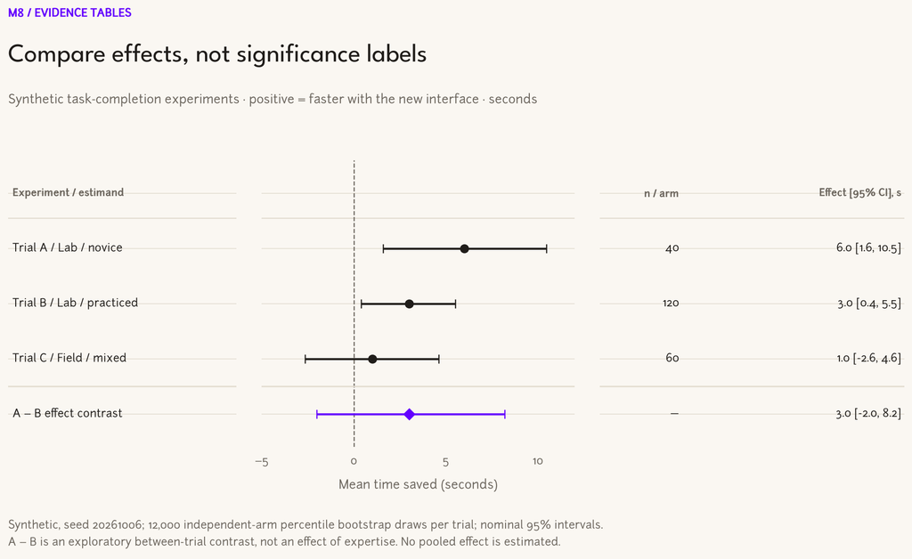

Figure 7: A forest-table hybrid carries setting, arm size, effect and interval. The fourth row compares two effects directly; it is not a pooled estimate.

```python
et.trials_figure()
plt.show()
```

A’s interval and B’s interval answer different within-trial questions. To compare their effects, calculate **A minus B** and its uncertainty. Under the independence assumption here, subtracting independent bootstrap draws gives the illustrated contrast distribution. The source code records the seed, 12,000 draws and percentile interval method. These nominal intervals have no multiplicity correction.

Do not infer a difference merely because one interval excludes zero and another does not. Cochrane’s [guidance on subgroup comparisons](https://www.cochrane.org/authors/handbooks-and-manuals/handbook/current/chapter-10) explains why the comparison itself needs analysis, and why across-study subgroup findings can be misleading. Here “novice” and “practiced” describe separate trials with different settings; the contrast does **not** identify a causal effect of expertise. The figure deliberately contains **no pooled diamond**.

```python
trial_rows, contrast_interval = et.synthetic_trials()
et.markdown_table(["Trial", "Setting", "People per arm", "Time saved (s)", "Nominal 95% bootstrap interval (s)"],
    [(r["trial"], r["setting"], r["n"], f'{r["effect"]:.1f}', f'{r["lo"]:.1f} to {r["hi"]:.1f}')
     for r in trial_rows] + [("A minus B", "Exploratory across-trial contrast", "Not applicable", "3.0",
        f"{contrast_interval[0]:.1f} to {contrast_interval[1]:.1f}")])
```

| Trial | Setting | People per arm | Time saved (s) | Nominal 95% bootstrap interval (s) |
| --- | --- | --- | --- | --- |
| A | Lab / novice | 40 | 6.0 | 1.6 to 10.5 |
| B | Lab / practiced | 120 | 3.0 | 0.4 to 5.5 |
| C | Field / mixed | 60 | 1.0 | -2.6 to 4.6 |
| A minus B | Exploratory across-trial contrast | Not applicable | 3.0 | -2.0 to 8.2 |

### The experimental-comparison design brief

Before drawing a multi-trial table, complete this brief. If a row changes the estimand, give it a new block; if an axis changes units, give it a new panel. A shared visual language must not imply a shared statistical model.

| Question | Consequence for the figure |
| --- | --- |
| Same people, independent people, or clusters? | Preserve pairing; report independent-unit counts; use an analysis that respects the design |
| Same endpoint and follow-up? | Separate incompatible endpoints/time windows; don’t pool just because numbers fit |
| Difference, ratio, or change from baseline? | Name the estimand and favorable direction; use the appropriate null reference |
| What uncertainty is shown? | State CI/SD/SE/quantiles and the estimation method; don’t mix them under one header |
| Several arms share one control? | Do not treat correlated contrasts as independent in a synthesis |
| Several outcomes or post-hoc subgroups? | Mark exploratory analyses and describe multiplicity handling rather than adding stars |
| Adjusted and unadjusted estimates? | Separate rows, label models/covariates, and keep sample/analysis populations explicit |
| Different settings? | Show setting beside the effect; do not label across-trial differences as causal moderators |

These are prompts to obtain the appropriate analysis, not a generic recipe for fitting one. The examples implement only the paired t calculation and independent-arm bootstrap explicitly described above.

## 10.5 A practical acceptance test

An evidence ledger is finished when a reviewer can:

- trace any mark horizontally to the correct identity, estimate and denominator;
- reproduce displayed values from the same arrays used by the plot, before rounding;
- tell a missing value, a tie, zero and not-applicable apart;
- name the estimand, units, interval method and direction without opening the code;
- distinguish an aggregate, subgroup, participant and contrast row;
- read the smallest text at the intended output size, without relying on color alone;
- retrieve exact values from an actual HTML table, not OCR from a PNG.

**Exercise:** add a fourth synthetic trial with a different follow-up. Resist squeezing it into the same effect column until you have decided whether it estimates the same quantity. Then design an executive card and a methods-appendix view from the same records. Explain every omitted column.

**Rule extracted:** a table inside a figure earns its area by supplying *auditability that the marks cannot*, not by repeating every plotted coordinate. Change the lookup burden for the audience; never change the evidence to suit the layout.

# The whole path, distilled

Nine modules: the original M0–M7 path plus M8, a new integrated-table and experimental-comparison workshop. Each leaves reusable guidance:

| Module | Principle | The lever it left behind |
| --- | --- | --- |
| **M0** | hold handles, not global state | the OO-API rule |
| **M1** | ask before you plot | `VISUALIZATION_GUIDE.md` (data shape × task → chart) |
| **M2** | the figure is the master coordinate | `subplot_mosaic`, small multiples, insets |
| **M3** | the page carries the legend | `page(dek=, dek_highlights=[...])` |
| **M4** | match the palette *type* to the data | `SERIES`, viridis, `diverging_norm` |
| **M5** | spend ink only on information | `finish(ax, grid=...)` |
| **M6** | one theme, three registers | `theme(register)` |
| **M7** | one dataset, two figures, exported right | `save(fig, stem)` |
| **M8** | tables and marks share an evidence contract | `evidence_tables.py`: aligned rows, audience views, paired and multi-trial comparisons |

The figures were always the byproduct. The deliverable is `CLAUDE.md` + `VISUALIZATION_GUIDE.md` + `house_style.py` — enough for any future agent to make a deliberate, defensible figure with zero re-explanation.